# Exercise

```python
%matplotlib notebook
import matplotlib.pyplot as plt
from skimage.io import imread, imshow
import numpy as np
import pandas as pd
```

## Read in your first x-ray image and display it using imshow()

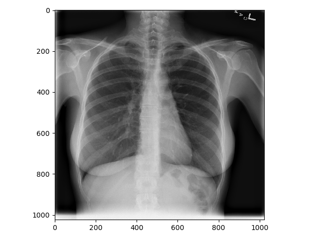

```python
chest_xray_1 = imread('chest_xray_1.png')
imshow(chest_xray_1)
```

## Fill in some coordinates for sections of the image that contain lung, heart, and bone:

```python
# Hovering your cursor over the image above will display your coordinates within the image at the bottom
# right corner of the figure. Use this to fill in starting and ending x & y values for lungs, heart, and bone
# in the chest x-ray image above

# An example for lung might be:
# lung_x = [210,265]
# lung_y = [380,430]

## Fill in your own values here:
lung_x = [210,265]
lung_y = [380,430]

heart_x = [515,600]
heart_y = [600,660]

bone_x = [420,480]
bone_y = [730,760]
```

## Now, plot the image intensities for the subsections that you chose using different coordinates for different structures:

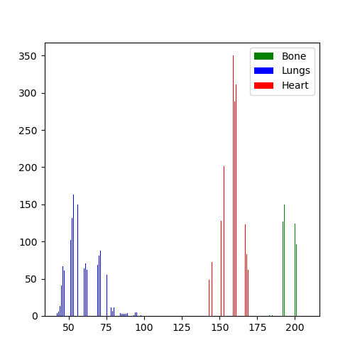

```python
plt.figure(figsize=(5,5))
plt.hist(chest_xray_1[bone_y[0]:bone_y[1],bone_x[0]:bone_x[1]].ravel(), bins = 256,color='green')
plt.hist(chest_xray_1[lung_y[0]:lung_y[1],lung_x[0]:lung_x[1]].ravel(),bins =256,color='blue')
plt.hist(chest_xray_1[heart_y[0]:heart_y[1],heart_x[0]:heart_x[1]].ravel(),bins=256,color='red')
plt.legend(['Bone','Lungs','Heart'])
plt.show()
```

## Now let's try with a less healthy looking chest x-ray:

Note that if you do **not turn off** the 'interactive' visualization by clicking the 'power' button in the xray imagee above, the new chest x-ray will replace the previous rather than being shown in a separate image below.

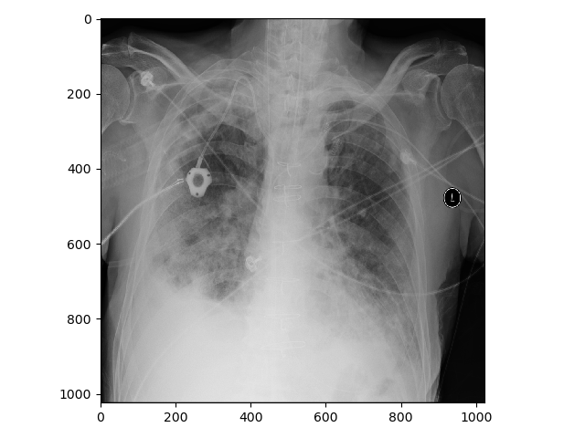

```python
## Note that if you do *not* turn off the 'interactive' visualization by clicking the 'power' button
# in the xray imagee above, the new chest x-ray will replace the previous rather than being shown in a separate image
# below.
chest_xray_3 = imread('chest_xray_3.png')
imshow(chest_xray_3)
```

```python
# Try the same exercise as above, selecting coordinates for lung, heart, and bone

## Fill in your own values here:
lung_x = [690,770]
lung_y = [500,590]

heart_x = [540,620]
heart_y = [750,800]

bone_x = [420,480]
bone_y = [710,770]
```

### Notice how the intensity values are different for the three structures compared to those in the first image:

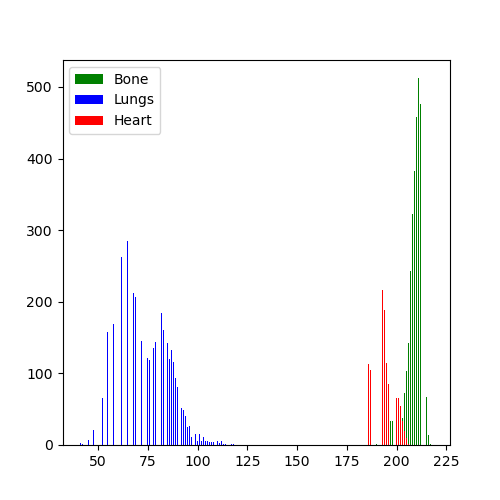

```python
plt.figure(figsize=(5,5))
plt.hist(chest_xray_3[bone_y[0]:bone_y[1],bone_x[0]:bone_x[1]].ravel(), bins = 256,color='green')
plt.hist(chest_xray_3[lung_y[0]:lung_y[1],lung_x[0]:lung_x[1]].ravel(),bins =256,color='blue')
plt.hist(chest_xray_3[heart_y[0]:heart_y[1],heart_x[0]:heart_x[1]].ravel(),bins=256,color='red')
plt.legend(['Bone','Lungs','Heart'])
plt.show()
```

## Finally, let's look at another type of image: mammography:

```python
mammo_left = imread('mammo_left.pgm')
mammo_right = imread('mammo_right.pgm')
```

#### First visualize the left breast:

Note that if you do **not turn off** the 'interactive' visualization by clicking the 'power' button in the xray imagee above, the new chest x-ray will replace the previous rather than being shown in a separate image below.

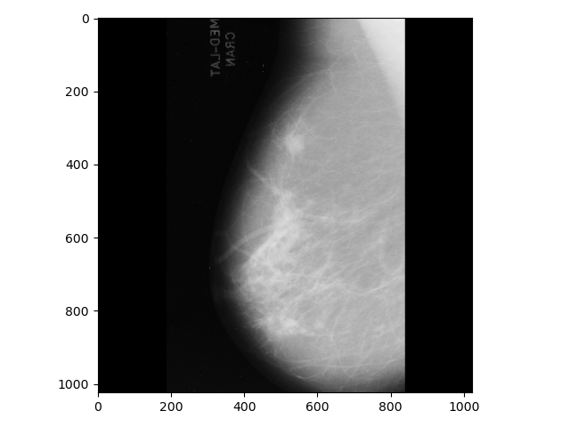

```python
 imshow(mammo_left)
```

```python
## The left breast has tumor in it, it's center is around [530,340]
## Choose coordinates that draw a box around it:

tumor_x = [510,560]
tumor_y = [315,375]
```

#### Now visualize the right breast:

Note that if you do **not turn off** the 'interactive' visualization by clicking the 'power' button in the xray imagee above, the new chest x-ray will replace the previous rather than being shown in a separate image below.

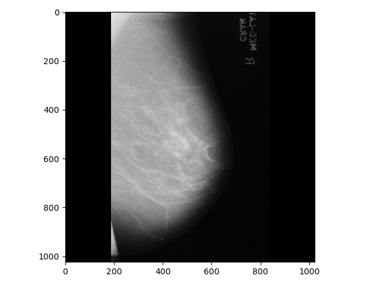

```python
imshow(mammo_right)
```

```python
## The right breast has no abnormalities, choose some coordinates that draw a box around a similar area
# of the breast tissue as you chose with the left:

normal_x = [360,450]
normal_y = [190,220]
```

### Now plot the intensity values of the two types of tissue:

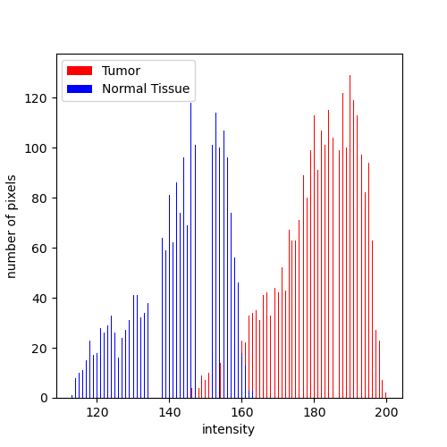

```python
plt.figure(figsize=(5,5))
plt.hist(mammo_left[tumor_y[0]:tumor_y[1],tumor_x[0]:tumor_x[1]].ravel(), bins = 256,color='red')
plt.hist(mammo_right[normal_y[0]:normal_y[1],normal_x[0]:normal_x[1]].ravel(),bins =256,color='blue')
plt.legend(['Tumor','Normal Tissue'])
plt.xlabel('intensity')
plt.ylabel('number of pixels')
plt.show()
```